# CCUsersChurnPrediction

### Problem Definition

- For Thera bank Customers with credit cards services is one of their important product which generate continuous revenue. The bank do not want customers to leave from this service else bank would loss money (revenue)
- As a Data scientist at Thera bank, I would need to come up with a classification model that will help the bank improve its services so that customers do not renounce their credit cards

#### Loading all required libraries to perform Assignment.

```python
# To help with reading and manipulating data
import pandas as pd
import numpy as np

# To help with data visualization
%matplotlib inline
import matplotlib.pyplot as plt
import seaborn as sns

# To be used for missing value imputation
from sklearn.impute import SimpleImputer

# To use statistical functions
import scipy.stats as stats

# To oversample and undersample data
from imblearn.over_sampling import SMOTE
from imblearn.under_sampling import RandomUnderSampler

# To help with model building
from sklearn.linear_model import LogisticRegression
from sklearn.tree import DecisionTreeClassifier
from sklearn.ensemble import (
    AdaBoostClassifier,
    GradientBoostingClassifier,
    RandomForestClassifier,
    BaggingClassifier,
)
from xgboost import XGBClassifier

# To get different metric scores, and split data
from sklearn import metrics
from sklearn.model_selection import train_test_split, StratifiedKFold, cross_val_score
from sklearn.metrics import (
    f1_score,
    accuracy_score,
    recall_score,
    precision_score,
    confusion_matrix,
    roc_auc_score,
    plot_confusion_matrix,
)

# To be used for data scaling and one hot encoding
from sklearn.preprocessing import StandardScaler, MinMaxScaler, OneHotEncoder

# To be used for tuning the model
from sklearn.model_selection import GridSearchCV, RandomizedSearchCV

# To be used for creating pipelines and personalizing them
from sklearn.pipeline import Pipeline
from sklearn.compose import ColumnTransformer

# To define maximum number of columns to be displayed in a dataframe
pd.set_option("display.max_columns", None)

# To supress scientific notations for a dataframe
pd.set_option("display.float_format", lambda x: "%.3f" % x)

# To supress warnings
import warnings

warnings.filterwarnings("ignore")

# This will help in making the Python code more structured automatically (good coding practice)
%load_ext nb_black
```

#### Load and overview the dataset

```python
# Loading the dataset
df = pd.read_csv("BankChurners.csv")
```

```python
# Checking the number of rows and columns in the data
df.shape
```

```
(10127, 21)
```

```python
# looking top 5 rows
df.head()
```

|  | CLIENTNUM | Attrition_Flag | Customer_Age | Gender | Dependent_count | Education_Level | Marital_Status | Income_Category | Card_Category | Months_on_book | Total_Relationship_Count | Months_Inactive_12_mon | Contacts_Count_12_mon | Credit_Limit | Total_Revolving_Bal | Avg_Open_To_Buy | Total_Amt_Chng_Q4_Q1 | Total_Trans_Amt | Total_Trans_Ct | Total_Ct_Chng_Q4_Q1 | Avg_Utilization_Ratio |
| --- | --- | --- | --- | --- | --- | --- | --- | --- | --- | --- | --- | --- | --- | --- | --- | --- | --- | --- | --- | --- | --- |
| 0 | 768805383 | Existing Customer | 45 | M | 3 | High School | Married | $60K - $80K | Blue | 39 | 5 | 1 | 3 | 12691.000 | 777 | 11914.000 | 1.335 | 1144 | 42 | 1.625 | 0.061 |
| 1 | 818770008 | Existing Customer | 49 | F | 5 | Graduate | Single | Less than $40K | Blue | 44 | 6 | 1 | 2 | 8256.000 | 864 | 7392.000 | 1.541 | 1291 | 33 | 3.714 | 0.105 |
| 2 | 713982108 | Existing Customer | 51 | M | 3 | Graduate | Married | $80K - $120K | Blue | 36 | 4 | 1 | 0 | 3418.000 | 0 | 3418.000 | 2.594 | 1887 | 20 | 2.333 | 0.000 |
| 3 | 769911858 | Existing Customer | 40 | F | 4 | High School | NaN | Less than $40K | Blue | 34 | 3 | 4 | 1 | 3313.000 | 2517 | 796.000 | 1.405 | 1171 | 20 | 2.333 | 0.760 |
| 4 | 709106358 | Existing Customer | 40 | M | 3 | Uneducated | Married | $60K - $80K | Blue | 21 | 5 | 1 | 0 | 4716.000 | 0 | 4716.000 | 2.175 | 816 | 28 | 2.500 | 0.000 |

```python
# looking into data types and non-nulls
df.info()
```

```
<class 'pandas.core.frame.DataFrame'>
RangeIndex: 10127 entries, 0 to 10126
Data columns (total 21 columns):
 #   Column                    Non-Null Count  Dtype
---  ------                    --------------  -----
 0   CLIENTNUM                 10127 non-null  int64
 1   Attrition_Flag            10127 non-null  object
 2   Customer_Age              10127 non-null  int64
 3   Gender                    10127 non-null  object
 4   Dependent_count           10127 non-null  int64
 5   Education_Level           8608 non-null   object
 6   Marital_Status            9378 non-null   object
 7   Income_Category           10127 non-null  object
 8   Card_Category             10127 non-null  object
 9   Months_on_book            10127 non-null  int64
 10  Total_Relationship_Count  10127 non-null  int64
 11  Months_Inactive_12_mon    10127 non-null  int64
 12  Contacts_Count_12_mon     10127 non-null  int64
 13  Credit_Limit              10127 non-null  float64
 14  Total_Revolving_Bal       10127 non-null  int64
 15  Avg_Open_To_Buy           10127 non-null  float64
 16  Total_Amt_Chng_Q4_Q1      10127 non-null  float64
 17  Total_Trans_Amt           10127 non-null  int64
 18  Total_Trans_Ct            10127 non-null  int64
 19  Total_Ct_Chng_Q4_Q1       10127 non-null  float64
 20  Avg_Utilization_Ratio     10127 non-null  float64
dtypes: float64(5), int64(10), object(6)
memory usage: 1.6+ MB
```

- It looks total record count is around 10127
- Education_Level & Marital_Status features have some missing values.

```python
# taking copy of the data set to do further analysis
data = df.copy()
```

```python
# To view the last 5 rows of the data
data.tail()
```

|  | CLIENTNUM | Attrition_Flag | Customer_Age | Gender | Dependent_count | Education_Level | Marital_Status | Income_Category | Card_Category | Months_on_book | Total_Relationship_Count | Months_Inactive_12_mon | Contacts_Count_12_mon | Credit_Limit | Total_Revolving_Bal | Avg_Open_To_Buy | Total_Amt_Chng_Q4_Q1 | Total_Trans_Amt | Total_Trans_Ct | Total_Ct_Chng_Q4_Q1 | Avg_Utilization_Ratio |
| --- | --- | --- | --- | --- | --- | --- | --- | --- | --- | --- | --- | --- | --- | --- | --- | --- | --- | --- | --- | --- | --- |
| 10122 | 772366833 | Existing Customer | 50 | M | 2 | Graduate | Single | $40K - $60K | Blue | 40 | 3 | 2 | 3 | 4003.000 | 1851 | 2152.000 | 0.703 | 15476 | 117 | 0.857 | 0.462 |
| 10123 | 710638233 | Attrited Customer | 41 | M | 2 | NaN | Divorced | $40K - $60K | Blue | 25 | 4 | 2 | 3 | 4277.000 | 2186 | 2091.000 | 0.804 | 8764 | 69 | 0.683 | 0.511 |
| 10124 | 716506083 | Attrited Customer | 44 | F | 1 | High School | Married | Less than $40K | Blue | 36 | 5 | 3 | 4 | 5409.000 | 0 | 5409.000 | 0.819 | 10291 | 60 | 0.818 | 0.000 |
| 10125 | 717406983 | Attrited Customer | 30 | M | 2 | Graduate | NaN | $40K - $60K | Blue | 36 | 4 | 3 | 3 | 5281.000 | 0 | 5281.000 | 0.535 | 8395 | 62 | 0.722 | 0.000 |
| 10126 | 714337233 | Attrited Customer | 43 | F | 2 | Graduate | Married | Less than $40K | Silver | 25 | 6 | 2 | 4 | 10388.000 | 1961 | 8427.000 | 0.703 | 10294 | 61 | 0.649 | 0.189 |

- At this point I want to convert Attrition_Flag to 0(Existing Customer) and 1 (Attrited Customer)

```python
# dependent variable converting to 0 and 1.
replaceAttrition_Flag = {"Existing Customer": 0, "Attrited Customer": 1}
```

```python
data = data.replace(replaceAttrition_Flag)
```

```python
# Converting from object to int
data = data.astype({"Attrition_Flag": np.int64})
```

```python
# to check the count after converting to 0s and 1s
data.Attrition_Flag.value_counts()
```

```
0    8500
1    1627
Name: Attrition_Flag, dtype: int64
```

#### checking duplicates, missing values and null values

```python
# To check for duplicate values in the data
data.duplicated().sum()
```

```
0
```

- No duplicates exists in the data set.

```python
# To check for missing values in the data
round(data.isnull().sum() / data.isnull().count() * 100, 2)
```

```
CLIENTNUM                   0.000
Attrition_Flag              0.000
Customer_Age                0.000
Gender                      0.000
Dependent_count             0.000
Education_Level            15.000
Marital_Status              7.400
Income_Category             0.000
Card_Category               0.000
Months_on_book              0.000
Total_Relationship_Count    0.000
Months_Inactive_12_mon      0.000
Contacts_Count_12_mon       0.000
Credit_Limit                0.000
Total_Revolving_Bal         0.000
Avg_Open_To_Buy             0.000
Total_Amt_Chng_Q4_Q1        0.000
Total_Trans_Amt             0.000
Total_Trans_Ct              0.000
Total_Ct_Chng_Q4_Q1         0.000
Avg_Utilization_Ratio       0.000
dtype: float64
```

```python
# Checking for the null value in the dataset
data.isna().sum()
```

```
CLIENTNUM                      0
Attrition_Flag                 0
Customer_Age                   0
Gender                         0
Dependent_count                0
Education_Level             1519
Marital_Status               749
Income_Category                0
Card_Category                  0
Months_on_book                 0
Total_Relationship_Count       0
Months_Inactive_12_mon         0
Contacts_Count_12_mon          0
Credit_Limit                   0
Total_Revolving_Bal            0
Avg_Open_To_Buy                0
Total_Amt_Chng_Q4_Q1           0
Total_Trans_Amt                0
Total_Trans_Ct                 0
Total_Ct_Chng_Q4_Q1            0
Avg_Utilization_Ratio          0
dtype: int64
```

- Education_Level field has about 1500 records null where as Marital_Status has about 750.

##### Finding unique values

```python
data.nunique()
```

```
CLIENTNUM                   10127
Attrition_Flag                  2
Customer_Age                   45
Gender                          2
Dependent_count                 6
Education_Level                 6
Marital_Status                  3
Income_Category                 6
Card_Category                   4
Months_on_book                 44
Total_Relationship_Count        6
Months_Inactive_12_mon          7
Contacts_Count_12_mon           7
Credit_Limit                 6205
Total_Revolving_Bal          1974
Avg_Open_To_Buy              6813
Total_Amt_Chng_Q4_Q1         1158
Total_Trans_Amt              5033
Total_Trans_Ct                126
Total_Ct_Chng_Q4_Q1           830
Avg_Utilization_Ratio         964
dtype: int64
```

```python
# to view statistical summary of the numerical columns in the data
data.describe().T
```

|  | count | mean | std | min | 25% | 50% | 75% | max |
| --- | --- | --- | --- | --- | --- | --- | --- | --- |
| CLIENTNUM | 10127.000 | 739177606.334 | 36903783.450 | 708082083.000 | 713036770.500 | 717926358.000 | 773143533.000 | 828343083.000 |
| Attrition_Flag | 10127.000 | 0.161 | 0.367 | 0.000 | 0.000 | 0.000 | 0.000 | 1.000 |
| Customer_Age | 10127.000 | 46.326 | 8.017 | 26.000 | 41.000 | 46.000 | 52.000 | 73.000 |
| Dependent_count | 10127.000 | 2.346 | 1.299 | 0.000 | 1.000 | 2.000 | 3.000 | 5.000 |
| Months_on_book | 10127.000 | 35.928 | 7.986 | 13.000 | 31.000 | 36.000 | 40.000 | 56.000 |
| Total_Relationship_Count | 10127.000 | 3.813 | 1.554 | 1.000 | 3.000 | 4.000 | 5.000 | 6.000 |
| Months_Inactive_12_mon | 10127.000 | 2.341 | 1.011 | 0.000 | 2.000 | 2.000 | 3.000 | 6.000 |
| Contacts_Count_12_mon | 10127.000 | 2.455 | 1.106 | 0.000 | 2.000 | 2.000 | 3.000 | 6.000 |
| Credit_Limit | 10127.000 | 8631.954 | 9088.777 | 1438.300 | 2555.000 | 4549.000 | 11067.500 | 34516.000 |
| Total_Revolving_Bal | 10127.000 | 1162.814 | 814.987 | 0.000 | 359.000 | 1276.000 | 1784.000 | 2517.000 |
| Avg_Open_To_Buy | 10127.000 | 7469.140 | 9090.685 | 3.000 | 1324.500 | 3474.000 | 9859.000 | 34516.000 |
| Total_Amt_Chng_Q4_Q1 | 10127.000 | 0.760 | 0.219 | 0.000 | 0.631 | 0.736 | 0.859 | 3.397 |
| Total_Trans_Amt | 10127.000 | 4404.086 | 3397.129 | 510.000 | 2155.500 | 3899.000 | 4741.000 | 18484.000 |
| Total_Trans_Ct | 10127.000 | 64.859 | 23.473 | 10.000 | 45.000 | 67.000 | 81.000 | 139.000 |
| Total_Ct_Chng_Q4_Q1 | 10127.000 | 0.712 | 0.238 | 0.000 | 0.582 | 0.702 | 0.818 | 3.714 |
| Avg_Utilization_Ratio | 10127.000 | 0.275 | 0.276 | 0.000 | 0.023 | 0.176 | 0.503 | 0.999 |

#### Observations -

- About 50 % of Customer's age is around 46. The max is around 73 years. If these are outliers it is okay to remove them.
- Not sure Dependent_count plays any role , I try to understand this from my EDA.
- About 50 % customers credit limit is 4500 where as for 75% the limit is with in 11000.
- Months_Inactive_12_mon & Contacts_Count_12_mon are almost having same type of data it may be okay to remove one of it.
- About Total Transaction amount is 3899 for 50 % means most of the credit limit amount is spending by these customers, these are very active ones.
- Total_Trans_Ct is also another one which is giving similar insight about the customer like Total_Trans_Amt, may be it is okay to drop One of it. I learn more from the correlation plot.

### Convert the columns with an 'object' datatype into categorical variables

```python
for feature in data.columns:  # Loop through all columns in the dataframe
    if (
        data[feature].dtype == "object"
    ):  # Only apply for columns with categorical strings
        data[feature] = pd.Categorical(data[feature])  # Replace strings with an integer
data.head(10)
for feature in data.columns:  # Loop through all columns in the dataframe
    if (
        data[feature].dtype == "object"
    ):  # Only apply for columns with categorical strings
        data[feature] = pd.Categorical(data[feature])  # Replace strings with an integer
data.head(10)
```

|  | CLIENTNUM | Attrition_Flag | Customer_Age | Gender | Dependent_count | Education_Level | Marital_Status | Income_Category | Card_Category | Months_on_book | Total_Relationship_Count | Months_Inactive_12_mon | Contacts_Count_12_mon | Credit_Limit | Total_Revolving_Bal | Avg_Open_To_Buy | Total_Amt_Chng_Q4_Q1 | Total_Trans_Amt | Total_Trans_Ct | Total_Ct_Chng_Q4_Q1 | Avg_Utilization_Ratio |
| --- | --- | --- | --- | --- | --- | --- | --- | --- | --- | --- | --- | --- | --- | --- | --- | --- | --- | --- | --- | --- | --- |
| 0 | 768805383 | 0 | 45 | M | 3 | High School | Married | $60K - $80K | Blue | 39 | 5 | 1 | 3 | 12691.000 | 777 | 11914.000 | 1.335 | 1144 | 42 | 1.625 | 0.061 |
| 1 | 818770008 | 0 | 49 | F | 5 | Graduate | Single | Less than $40K | Blue | 44 | 6 | 1 | 2 | 8256.000 | 864 | 7392.000 | 1.541 | 1291 | 33 | 3.714 | 0.105 |
| 2 | 713982108 | 0 | 51 | M | 3 | Graduate | Married | $80K - $120K | Blue | 36 | 4 | 1 | 0 | 3418.000 | 0 | 3418.000 | 2.594 | 1887 | 20 | 2.333 | 0.000 |
| 3 | 769911858 | 0 | 40 | F | 4 | High School | NaN | Less than $40K | Blue | 34 | 3 | 4 | 1 | 3313.000 | 2517 | 796.000 | 1.405 | 1171 | 20 | 2.333 | 0.760 |
| 4 | 709106358 | 0 | 40 | M | 3 | Uneducated | Married | $60K - $80K | Blue | 21 | 5 | 1 | 0 | 4716.000 | 0 | 4716.000 | 2.175 | 816 | 28 | 2.500 | 0.000 |
| 5 | 713061558 | 0 | 44 | M | 2 | Graduate | Married | $40K - $60K | Blue | 36 | 3 | 1 | 2 | 4010.000 | 1247 | 2763.000 | 1.376 | 1088 | 24 | 0.846 | 0.311 |
| 6 | 810347208 | 0 | 51 | M | 4 | NaN | Married | $120K + | Gold | 46 | 6 | 1 | 3 | 34516.000 | 2264 | 32252.000 | 1.975 | 1330 | 31 | 0.722 | 0.066 |
| 7 | 818906208 | 0 | 32 | M | 0 | High School | NaN | $60K - $80K | Silver | 27 | 2 | 2 | 2 | 29081.000 | 1396 | 27685.000 | 2.204 | 1538 | 36 | 0.714 | 0.048 |
| 8 | 710930508 | 0 | 37 | M | 3 | Uneducated | Single | $60K - $80K | Blue | 36 | 5 | 2 | 0 | 22352.000 | 2517 | 19835.000 | 3.355 | 1350 | 24 | 1.182 | 0.113 |
| 9 | 719661558 | 0 | 48 | M | 2 | Graduate | Single | $80K - $120K | Blue | 36 | 6 | 3 | 3 | 11656.000 | 1677 | 9979.000 | 1.524 | 1441 | 32 | 0.882 | 0.144 |

```python
data.info()
```

```
<class 'pandas.core.frame.DataFrame'>
RangeIndex: 10127 entries, 0 to 10126
Data columns (total 21 columns):
 #   Column                    Non-Null Count  Dtype
---  ------                    --------------  -----
 0   CLIENTNUM                 10127 non-null  int64
 1   Attrition_Flag            10127 non-null  int64
 2   Customer_Age              10127 non-null  int64
 3   Gender                    10127 non-null  category
 4   Dependent_count           10127 non-null  int64
 5   Education_Level           8608 non-null   category
 6   Marital_Status            9378 non-null   category
 7   Income_Category           10127 non-null  category
 8   Card_Category             10127 non-null  category
 9   Months_on_book            10127 non-null  int64
 10  Total_Relationship_Count  10127 non-null  int64
 11  Months_Inactive_12_mon    10127 non-null  int64
 12  Contacts_Count_12_mon     10127 non-null  int64
 13  Credit_Limit              10127 non-null  float64
 14  Total_Revolving_Bal       10127 non-null  int64
 15  Avg_Open_To_Buy           10127 non-null  float64
 16  Total_Amt_Chng_Q4_Q1      10127 non-null  float64
 17  Total_Trans_Amt           10127 non-null  int64
 18  Total_Trans_Ct            10127 non-null  int64
 19  Total_Ct_Chng_Q4_Q1       10127 non-null  float64
 20  Avg_Utilization_Ratio     10127 non-null  float64
dtypes: category(5), float64(5), int64(11)
memory usage: 1.3 MB
```

```python
# Making a list of all catrgorical variables
cat_cols = [
    "Attrition_Flag",
    "Gender",
    "Education_Level",
    "Marital_Status",
    "Income_Category",
    "Card_Category",
    "Total_Relationship_Count",
    "Months_Inactive_12_mon",
    "Contacts_Count_12_mon",
    "Dependent_count",
]

numerical_cols = [
    "Credit_Limit",
    "Total_Revolving_Bal",
    "Avg_Open_To_Buy",
    "Total_Amt_Chng_Q4_Q1",
    "Total_Trans_Amt",
    "Total_Trans_Ct",
    "Total_Ct_Chng_Q4_Q1",
    "Avg_Utilization_Ratio",
]

# Printing number of count of each unique value in each column
for column in cat_cols:
    print(data[column].value_counts())
    print("-" * 40)
```

```
0    8500
1    1627
Name: Attrition_Flag, dtype: int64
----------------------------------------
F    5358
M    4769
Name: Gender, dtype: int64
----------------------------------------
Graduate         3128
High School      2013
Uneducated       1487
College          1013
Post-Graduate     516
Doctorate         451
Name: Education_Level, dtype: int64
----------------------------------------
Married     4687
Single      3943
Divorced     748
Name: Marital_Status, dtype: int64
----------------------------------------
Less than $40K    3561
$40K - $60K       1790
$80K - $120K      1535
$60K - $80K       1402
abc               1112
$120K +            727
Name: Income_Category, dtype: int64
----------------------------------------
Blue        9436
Silver       555
Gold         116
Platinum      20
Name: Card_Category, dtype: int64
----------------------------------------
3    2305
4    1912
5    1891
6    1866
2    1243
```

[output cut: 14 more lines]

```
1    1499
4    1392
0     399
5     176
6      54
Name: Contacts_Count_12_mon, dtype: int64
----------------------------------------
3    2732
2    2655
1    1838
4    1574
0     904
5     424
Name: Dependent_count, dtype: int64
----------------------------------------
```

- About 1110 records, Income_Category is having incorrect value 'abc', this needs to be replaced with either 'un-known' or 'other'. Personally I do not like to replace this with mode or mean. since we do not know the root-cause for this missing value.

### Univariate Analysis on Numerical variables

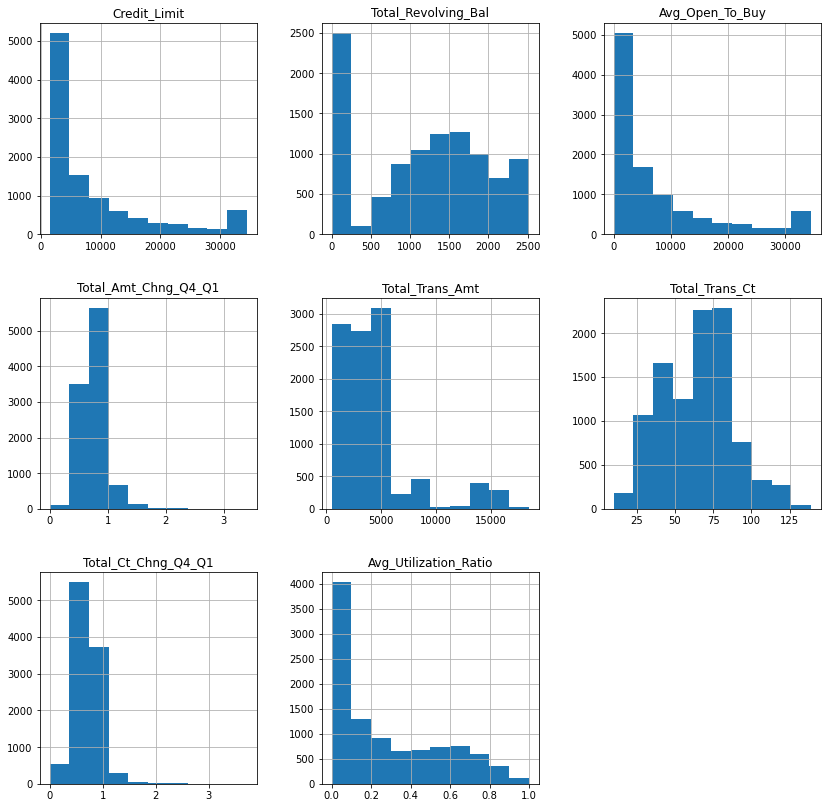

```python
# creating histograms
data[numerical_cols].hist(figsize=(14, 14))
plt.show()
```

#### Few details about Numerical variables

- Credit_Limit : The distribution of the Credit_Limit is right-skewed, there are outliers at the right end.
- Avg_Open_to_Buy - The distribution of the Credit_Limit is right-skewed, there are outliers at the right end.
- Total_Amt_Chng_Q4_Q1, Total_ct_Chng_Q4_Q1 are sharing same type of information, it may be okay to drop one of the column.
- Avg_Utilization_Ratio is right-skewed.
- Total transaction amount and total transaction count are skewed on both sides.
- I'm not going to treat these outliers as they represent the real market trend.
- I may drop couple of these feautures after peeking into scatter plot.

```python
# function to plot a boxplot and a histogram along the same scale.


def histogram_boxplot(data, feature, figsize=(12, 7), kde=False, bins=None):
    """
    Boxplot and histogram combined

    data: dataframe
    feature: dataframe column
    figsize: size of figure (default (12,7))
    kde: whether to the show density curve (default False)
    bins: number of bins for histogram (default None)
    """
    f2, (ax_box2, ax_hist2) = plt.subplots(
        nrows=2,  # Number of rows of the subplot grid= 2
        sharex=True,  # x-axis will be shared among all subplots
        gridspec_kw={"height_ratios": (0.25, 0.75)},
        figsize=figsize,
    )  # creating the 2 subplots
    sns.boxplot(
        data=data, x=feature, ax=ax_box2, showmeans=True, color="violet"
    )  # boxplot will be created and a star will indicate the mean value of the column
    sns.histplot(
        data=data, x=feature, kde=kde, ax=ax_hist2, bins=bins, palette="winter"
    ) if bins else sns.histplot(
        data=data, x=feature, kde=kde, ax=ax_hist2
    )  # For histogram
    ax_hist2.axvline(
        data[feature].mean(), color="green", linestyle="--"
    )  # Add mean to the histogram
    ax_hist2.axvline(
        data[feature].median(), color="black", linestyle="-"
    )  # Add median to the histogram
```

#### Observation on Customer Age

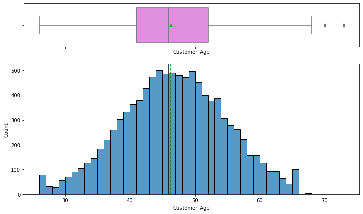

```python
# Observations on Customer_age
histogram_boxplot(data, "Customer_Age")
```

- The distribution of age is almost symmetrical
- There are outliers at the right end.
- I'm going to delete these records if the count is small, If age is more like above 70 years,there are potential chances of customers not to use the card due to health or other issues. Hence decided to delete them, if count is very small.

### Univariate Analysis on Categorical variables

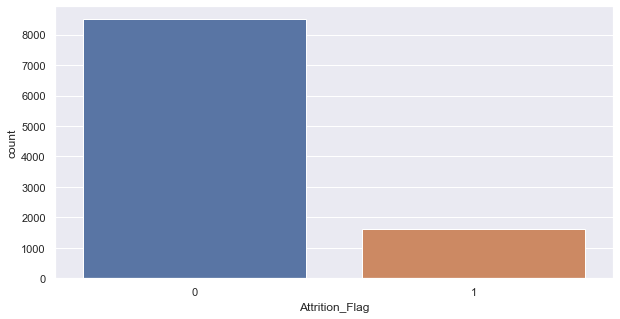

[figure not shown]

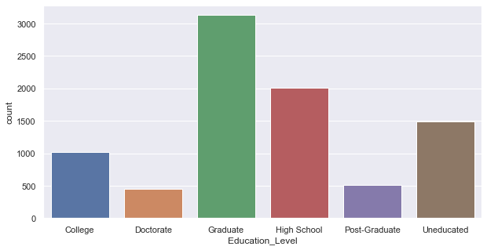

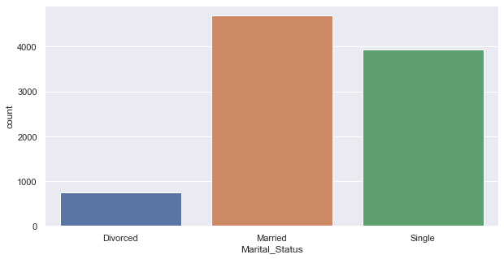

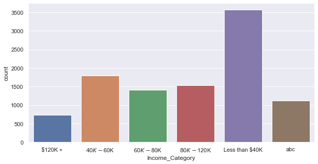

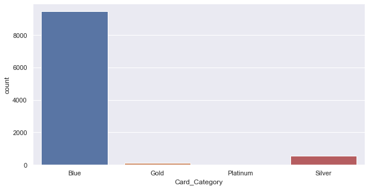

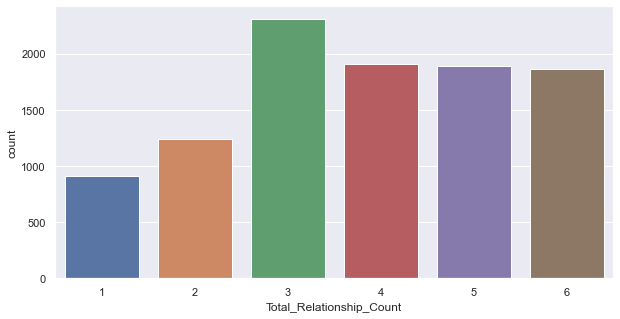

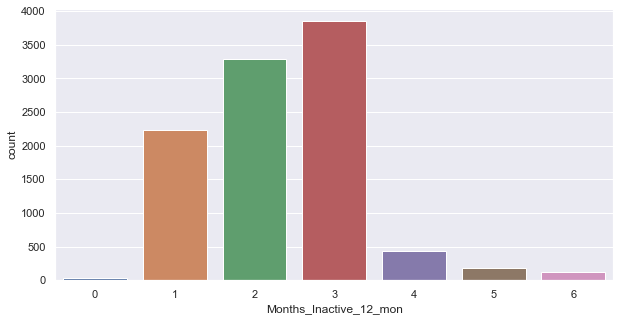

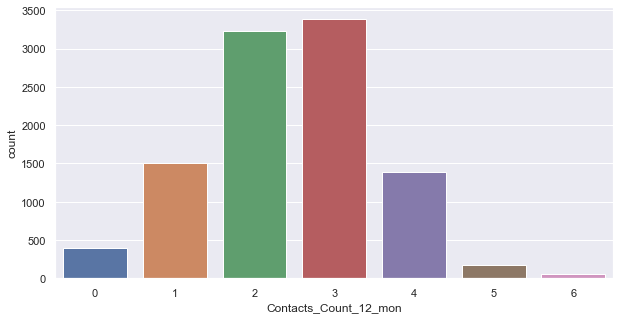

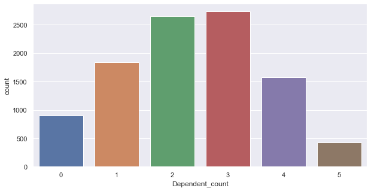

```python
fig, axes = plt.subplots(1, 2)
fig.suptitle("Count Plot for Categorical Features")
sns.set(rc={"figure.figsize": (10, 5)})

# Loop over all columns
for i, col in enumerate(cat_cols):
    plt.figure(i)
    sns.countplot(x=col, data=data)
plt.show()
```

### Bivariate EDA

- I have analyzed different categorical and numerical variables.
- I'm going to check how different variables are related to each other using correlation plot.

### Correlation Plot

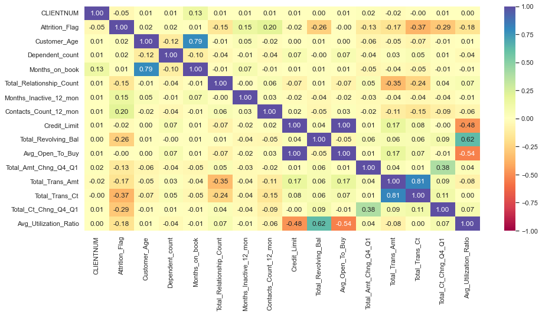

```python
plt.figure(figsize=(15, 7))
sns.heatmap(data.corr(), annot=True, vmin=-1, vmax=1, fmt=".2f", cmap="Spectral")
plt.show()
```

##### Checking the relationship between Attrition_flag and Numerical variables

```python
# Mean of numerical variables grouped by attrition
data.groupby(["Attrition_Flag"])[numerical_cols].mean()
```

| Attrition_Flag | Credit_Limit | Total_Revolving_Bal | Avg_Open_To_Buy | Total_Amt_Chng_Q4_Q1 | Total_Trans_Amt | Total_Trans_Ct | Total_Ct_Chng_Q4_Q1 | Avg_Utilization_Ratio |
| --- | --- | --- | --- | --- | --- | --- | --- | --- |
| 0 | 8726.878 | 1256.604 | 7470.273 | 0.773 | 4654.656 | 68.673 | 0.742 | 0.296 |
| 1 | 8136.039 | 672.823 | 7463.216 | 0.694 | 3095.026 | 44.934 | 0.554 | 0.162 |

- Total revolving balance for attrited is 50 % less compared to existing customers.

##### Checking the relationship between Attrition_flag and Categorical variables

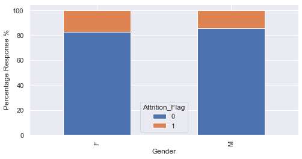

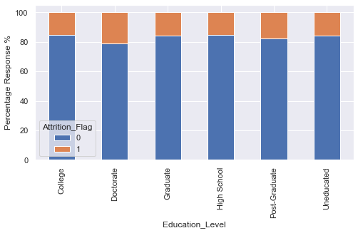

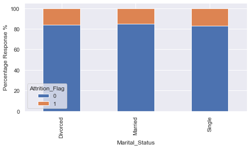

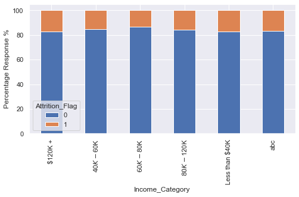

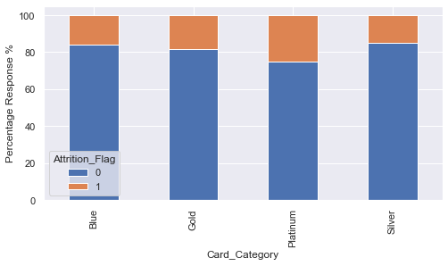

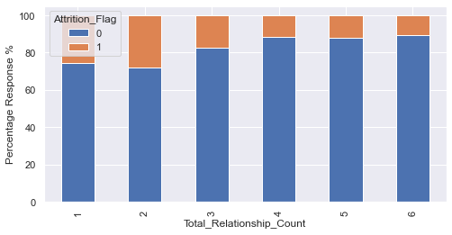

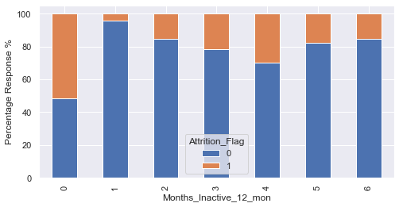

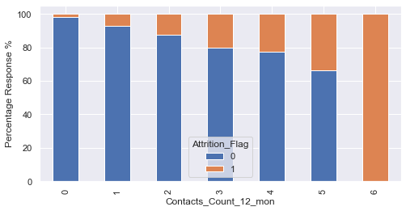

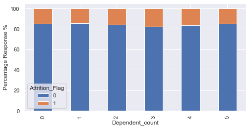

```python
for i in cat_cols:
    if i != "Attrition_Flag":
        (pd.crosstab(data[i], data["Attrition_Flag"], normalize="index") * 100).plot(
            kind="bar", figsize=(8, 4), stacked=True
        )
        plt.ylabel("Percentage Response %")
```

- Both male and female are almost equally in both attrition flag buckets
- Almost with other categorical columns noted same
- Except with Total_Relationship_Count & Months_Inactive_12_mon. These two have more attrited customers.
- Customers having Contacts_count_12_mon = 6 are all are attrited customers.

### Data Pre-Processing & Feature Engineering

- We can drop the column - CLIENTNUM - it is unique ID for each customer and not add value to the model.

```python
# Dropping column - CLIENTNUM
data.drop(columns=["CLIENTNUM"], inplace=True)
```

```python
# Replacing 2n Cycle with Master
data["Income_Category"] = data["Income_Category"].replace("abc", "Un-Known")
```

```python
data.Income_Category.value_counts()
```

```
Less than $40K    3561
$40K - $60K       1790
$80K - $120K      1535
$60K - $80K       1402
Un-Known          1112
$120K +            727
Name: Income_Category, dtype: int64
```

### Outliers treatment

```python
data.describe().T
```

|  | count | mean | std | min | 25% | 50% | 75% | max |
| --- | --- | --- | --- | --- | --- | --- | --- | --- |
| Attrition_Flag | 10127.000 | 0.161 | 0.367 | 0.000 | 0.000 | 0.000 | 0.000 | 1.000 |
| Customer_Age | 10127.000 | 46.326 | 8.017 | 26.000 | 41.000 | 46.000 | 52.000 | 73.000 |
| Dependent_count | 10127.000 | 2.346 | 1.299 | 0.000 | 1.000 | 2.000 | 3.000 | 5.000 |
| Months_on_book | 10127.000 | 35.928 | 7.986 | 13.000 | 31.000 | 36.000 | 40.000 | 56.000 |
| Total_Relationship_Count | 10127.000 | 3.813 | 1.554 | 1.000 | 3.000 | 4.000 | 5.000 | 6.000 |
| Months_Inactive_12_mon | 10127.000 | 2.341 | 1.011 | 0.000 | 2.000 | 2.000 | 3.000 | 6.000 |
| Contacts_Count_12_mon | 10127.000 | 2.455 | 1.106 | 0.000 | 2.000 | 2.000 | 3.000 | 6.000 |
| Credit_Limit | 10127.000 | 8631.954 | 9088.777 | 1438.300 | 2555.000 | 4549.000 | 11067.500 | 34516.000 |
| Total_Revolving_Bal | 10127.000 | 1162.814 | 814.987 | 0.000 | 359.000 | 1276.000 | 1784.000 | 2517.000 |
| Avg_Open_To_Buy | 10127.000 | 7469.140 | 9090.685 | 3.000 | 1324.500 | 3474.000 | 9859.000 | 34516.000 |
| Total_Amt_Chng_Q4_Q1 | 10127.000 | 0.760 | 0.219 | 0.000 | 0.631 | 0.736 | 0.859 | 3.397 |
| Total_Trans_Amt | 10127.000 | 4404.086 | 3397.129 | 510.000 | 2155.500 | 3899.000 | 4741.000 | 18484.000 |
| Total_Trans_Ct | 10127.000 | 64.859 | 23.473 | 10.000 | 45.000 | 67.000 | 81.000 | 139.000 |
| Total_Ct_Chng_Q4_Q1 | 10127.000 | 0.712 | 0.238 | 0.000 | 0.582 | 0.702 | 0.818 | 3.714 |
| Avg_Utilization_Ratio | 10127.000 | 0.275 | 0.276 | 0.000 | 0.023 | 0.176 | 0.503 | 0.999 |

```python
data[data["Customer_Age"] > 68]
```

|  | Attrition_Flag | Customer_Age | Gender | Dependent_count | Education_Level | Marital_Status | Income_Category | Card_Category | Months_on_book | Total_Relationship_Count | Months_Inactive_12_mon | Contacts_Count_12_mon | Credit_Limit | Total_Revolving_Bal | Avg_Open_To_Buy | Total_Amt_Chng_Q4_Q1 | Total_Trans_Amt | Total_Trans_Ct | Total_Ct_Chng_Q4_Q1 | Avg_Utilization_Ratio |
| --- | --- | --- | --- | --- | --- | --- | --- | --- | --- | --- | --- | --- | --- | --- | --- | --- | --- | --- | --- | --- |
| 251 | 0 | 73 | M | 0 | High School | Married | $40K - $60K | Blue | 36 | 5 | 3 | 2 | 4469.000 | 1125 | 3344.000 | 1.363 | 1765 | 34 | 1.615 | 0.252 |
| 254 | 0 | 70 | M | 0 | High School | Married | Less than $40K | Blue | 56 | 3 | 2 | 3 | 3252.000 | 1495 | 1757.000 | 0.581 | 1227 | 15 | 0.875 | 0.460 |

```python
# Since there are only two customers above 70 years and they may not use the card more often due to age. Hence removing them.

data.drop(data[data.Customer_Age > 68].index, inplace=True)
```

```python
data[data["Credit_Limit"] > 34000]
```

|  | Attrition_Flag | Customer_Age | Gender | Dependent_count | Education_Level | Marital_Status | Income_Category | Card_Category | Months_on_book | Total_Relationship_Count | Months_Inactive_12_mon | Contacts_Count_12_mon | Credit_Limit | Total_Revolving_Bal | Avg_Open_To_Buy | Total_Amt_Chng_Q4_Q1 | Total_Trans_Amt | Total_Trans_Ct | Total_Ct_Chng_Q4_Q1 | Avg_Utilization_Ratio |
| --- | --- | --- | --- | --- | --- | --- | --- | --- | --- | --- | --- | --- | --- | --- | --- | --- | --- | --- | --- | --- |
| 6 | 0 | 51 | M | 4 | NaN | Married | $120K + | Gold | 46 | 6 | 1 | 3 | 34516.000 | 2264 | 32252.000 | 1.975 | 1330 | 31 | 0.722 | 0.066 |
| 45 | 0 | 49 | M | 4 | Uneducated | Single | $80K - $120K | Blue | 30 | 3 | 2 | 3 | 34516.000 | 0 | 34516.000 | 1.621 | 1444 | 28 | 1.333 | 0.000 |
| 61 | 1 | 48 | M | 2 | Graduate | Married | $60K - $80K | Silver | 35 | 2 | 4 | 4 | 34516.000 | 0 | 34516.000 | 0.763 | 691 | 15 | 0.500 | 0.000 |
| 65 | 0 | 51 | M | 4 | Uneducated | Single | $80K - $120K | Silver | 38 | 4 | 1 | 4 | 34516.000 | 1515 | 33001.000 | 0.592 | 1293 | 32 | 0.600 | 0.044 |
| 70 | 0 | 51 | M | 4 | Graduate | Single | $120K + | Blue | 42 | 3 | 2 | 3 | 34516.000 | 1763 | 32753.000 | 1.266 | 1550 | 41 | 1.050 | 0.051 |
| ... | ... | ... | ... | ... | ... | ... | ... | ... | ... | ... | ... | ... | ... | ... | ... | ... | ... | ... | ... | ... |
| 10088 | 0 | 45 | M | 2 | Graduate | Single | $60K - $80K | Silver | 33 | 4 | 2 | 2 | 34516.000 | 1529 | 32987.000 | 0.609 | 13940 | 105 | 0.810 | 0.044 |
| 10095 | 0 | 46 | M | 3 | NaN | Married | $80K - $120K | Blue | 33 | 4 | 1 | 3 | 34516.000 | 1099 | 33417.000 | 0.816 | 15490 | 110 | 0.618 | 0.032 |
| 10098 | 1 | 55 | M | 3 | Graduate | Single | $120K + | Silver | 36 | 4 | 3 | 4 | 34516.000 | 0 | 34516.000 | 1.007 | 9931 | 70 | 0.750 | 0.000 |
| 10110 | 0 | 56 | M | 1 | Graduate | Single | $80K - $120K | Silver | 49 | 5 | 2 | 2 | 34516.000 | 1091 | 33425.000 | 0.640 | 15274 | 108 | 0.714 | 0.032 |
| 10112 | 1 | 33 | M | 2 | College | Married | $120K + | Gold | 20 | 2 | 1 | 4 | 34516.000 | 0 | 34516.000 | 1.004 | 9338 | 73 | 0.622 | 0.000 |

517 rows × 20 columns

- Credit_limit: About 500 cusotmers have more than 34000 credit limit. A good number and not to consider this as an outlier.

```python
data[data["Total_Revolving_Bal"] > 2500]
```

|  | Attrition_Flag | Customer_Age | Gender | Dependent_count | Education_Level | Marital_Status | Income_Category | Card_Category | Months_on_book | Total_Relationship_Count | Months_Inactive_12_mon | Contacts_Count_12_mon | Credit_Limit | Total_Revolving_Bal | Avg_Open_To_Buy | Total_Amt_Chng_Q4_Q1 | Total_Trans_Amt | Total_Trans_Ct | Total_Ct_Chng_Q4_Q1 | Avg_Utilization_Ratio |
| --- | --- | --- | --- | --- | --- | --- | --- | --- | --- | --- | --- | --- | --- | --- | --- | --- | --- | --- | --- | --- |
| 3 | 0 | 40 | F | 4 | High School | NaN | Less than $40K | Blue | 34 | 3 | 4 | 1 | 3313.000 | 2517 | 796.000 | 1.405 | 1171 | 20 | 2.333 | 0.760 |
| 8 | 0 | 37 | M | 3 | Uneducated | Single | $60K - $80K | Blue | 36 | 5 | 2 | 0 | 22352.000 | 2517 | 19835.000 | 3.355 | 1350 | 24 | 1.182 | 0.113 |
| 18 | 0 | 61 | M | 1 | High School | Married | $40K - $60K | Blue | 56 | 2 | 2 | 3 | 3193.000 | 2517 | 676.000 | 1.831 | 1336 | 30 | 1.143 | 0.788 |
| 32 | 0 | 41 | M | 4 | Graduate | Married | $60K - $80K | Blue | 36 | 4 | 1 | 2 | 8923.000 | 2517 | 6406.000 | 1.726 | 1589 | 24 | 1.667 | 0.282 |
| 42 | 0 | 50 | F | 1 | College | Single | $40K - $60K | Silver | 43 | 3 | 2 | 3 | 17304.000 | 2517 | 14787.000 | 1.449 | 1756 | 33 | 1.200 | 0.145 |
| ... | ... | ... | ... | ... | ... | ... | ... | ... | ... | ... | ... | ... | ... | ... | ... | ... | ... | ... | ... | ... |
| 10071 | 1 | 37 | M | 3 | NaN | Single | $40K - $60K | Blue | 29 | 6 | 2 | 3 | 13589.000 | 2517 | 11072.000 | 0.941 | 9456 | 79 | 1.026 | 0.185 |
| 10078 | 0 | 40 | M | 3 | High School | Divorced | $60K - $80K | Blue | 36 | 3 | 1 | 2 | 16268.000 | 2517 | 13751.000 | 0.652 | 15925 | 124 | 0.824 | 0.155 |
| 10079 | 0 | 45 | M | 4 | Graduate | Single | $60K - $80K | Silver | 36 | 2 | 3 | 4 | 28564.000 | 2517 | 26047.000 | 0.711 | 14875 | 107 | 0.783 | 0.088 |
| 10113 | 1 | 27 | M | 0 | High School | Divorced | $60K - $80K | Blue | 36 | 2 | 3 | 2 | 13303.000 | 2517 | 10786.000 | 0.929 | 10219 | 85 | 0.809 | 0.189 |
| 10119 | 1 | 55 | F | 3 | Uneducated | Single | Un-Known | Blue | 47 | 4 | 3 | 3 | 14657.000 | 2517 | 12140.000 | 0.166 | 6009 | 53 | 0.514 | 0.172 |

529 rows × 20 columns

- Total_Revolving_Bal: About 500 cusotmers have more than 2500 revolving balance. A good number and not to consider this as an outlier.

```python
data[data["Avg_Open_To_Buy"] > 34500]
```

|  | Attrition_Flag | Customer_Age | Gender | Dependent_count | Education_Level | Marital_Status | Income_Category | Card_Category | Months_on_book | Total_Relationship_Count | Months_Inactive_12_mon | Contacts_Count_12_mon | Credit_Limit | Total_Revolving_Bal | Avg_Open_To_Buy | Total_Amt_Chng_Q4_Q1 | Total_Trans_Amt | Total_Trans_Ct | Total_Ct_Chng_Q4_Q1 | Avg_Utilization_Ratio |
| --- | --- | --- | --- | --- | --- | --- | --- | --- | --- | --- | --- | --- | --- | --- | --- | --- | --- | --- | --- | --- |
| 45 | 0 | 49 | M | 4 | Uneducated | Single | $80K - $120K | Blue | 30 | 3 | 2 | 3 | 34516.000 | 0 | 34516.000 | 1.621 | 1444 | 28 | 1.333 | 0.000 |
| 61 | 1 | 48 | M | 2 | Graduate | Married | $60K - $80K | Silver | 35 | 2 | 4 | 4 | 34516.000 | 0 | 34516.000 | 0.763 | 691 | 15 | 0.500 | 0.000 |
| 237 | 0 | 44 | M | 3 | Graduate | NaN | $80K - $120K | Blue | 33 | 3 | 3 | 3 | 34516.000 | 0 | 34516.000 | 0.483 | 1120 | 27 | 0.350 | 0.000 |
| 321 | 0 | 48 | M | 3 | Graduate | Single | $80K - $120K | Silver | 37 | 3 | 2 | 3 | 34516.000 | 0 | 34516.000 | 0.448 | 1122 | 13 | 0.182 | 0.000 |
| 345 | 0 | 49 | M | 1 | Graduate | Married | $120K + | Blue | 39 | 3 | 2 | 3 | 34516.000 | 0 | 34516.000 | 0.507 | 1106 | 31 | 0.938 | 0.000 |
| ... | ... | ... | ... | ... | ... | ... | ... | ... | ... | ... | ... | ... | ... | ... | ... | ... | ... | ... | ... | ... |
| 9950 | 1 | 45 | M | 5 | Uneducated | Single | $120K + | Silver | 36 | 4 | 2 | 1 | 34516.000 | 0 | 34516.000 | 0.732 | 8603 | 84 | 0.615 | 0.000 |
| 9986 | 0 | 50 | M | 3 | High School | Single | $80K - $120K | Silver | 41 | 2 | 2 | 1 | 34516.000 | 0 | 34516.000 | 0.627 | 15059 | 118 | 0.735 | 0.000 |
| 9997 | 0 | 49 | M | 3 | High School | Married | $60K - $80K | Gold | 42 | 3 | 1 | 4 | 34516.000 | 0 | 34516.000 | 0.838 | 15095 | 102 | 0.759 | 0.000 |
| 10098 | 1 | 55 | M | 3 | Graduate | Single | $120K + | Silver | 36 | 4 | 3 | 4 | 34516.000 | 0 | 34516.000 | 1.007 | 9931 | 70 | 0.750 | 0.000 |
| 10112 | 1 | 33 | M | 2 | College | Married | $120K + | Gold | 20 | 2 | 1 | 4 | 34516.000 | 0 | 34516.000 | 1.004 | 9338 | 73 | 0.622 | 0.000 |

98 rows × 20 columns

- Avg_Open_To_Buy: About 100 cusotmers have more than 34500 open to buy. A good number and not to consider this as an outlier.

```python
data[data["Total_Trans_Amt"] > 17500]
```

|  | Attrition_Flag | Customer_Age | Gender | Dependent_count | Education_Level | Marital_Status | Income_Category | Card_Category | Months_on_book | Total_Relationship_Count | Months_Inactive_12_mon | Contacts_Count_12_mon | Credit_Limit | Total_Revolving_Bal | Avg_Open_To_Buy | Total_Amt_Chng_Q4_Q1 | Total_Trans_Amt | Total_Trans_Ct | Total_Ct_Chng_Q4_Q1 | Avg_Utilization_Ratio |
| --- | --- | --- | --- | --- | --- | --- | --- | --- | --- | --- | --- | --- | --- | --- | --- | --- | --- | --- | --- | --- |
| 9341 | 0 | 48 | M | 2 | High School | Married | Less than $40K | Silver | 36 | 2 | 2 | 2 | 14581.000 | 2517 | 12064.000 | 0.776 | 17628 | 109 | 0.817 | 0.173 |
| 9601 | 0 | 45 | M | 4 | High School | Single | $60K - $80K | Blue | 35 | 1 | 1 | 3 | 8449.000 | 2092 | 6357.000 | 0.709 | 17634 | 120 | 0.667 | 0.248 |
| 9964 | 0 | 47 | M | 4 | NaN | Married | $60K - $80K | Blue | 36 | 4 | 5 | 2 | 10585.000 | 1749 | 8836.000 | 0.655 | 18484 | 108 | 0.588 | 0.165 |
| 10073 | 0 | 51 | M | 2 | Graduate | Married | $60K - $80K | Blue | 40 | 3 | 3 | 3 | 3750.000 | 1801 | 1949.000 | 0.889 | 17995 | 116 | 0.657 | 0.480 |
| 10097 | 0 | 31 | M | 0 | High School | Single | $40K - $60K | Blue | 25 | 3 | 2 | 3 | 4493.000 | 1388 | 3105.000 | 0.795 | 17744 | 104 | 0.763 | 0.309 |

- Total_Trans_Amt: Though the transaction amount seems pretty high and appear as outliers, but by looking in to other data like Total_Trans_Ct is also high. These are very active customers.

##### I have identified these columns are safe to drop for these reasons:

- Total_Trans_Amt and Total_Trans_ct are highly correlated (.81)hence dropping Total_Trans_Amt
- Months_on_book feature is very low correlated to dependent variable (Attrition_flag) , Hence dropping them.
- Credit_Limit and Avg_Open_to_buy are highly correlated (1.0 )hence dropping Avg_Open_to_buy.
- Total_Amt_Chng_Q4_Q1 & Total_Ct_Chng_Q4_Q1 are sharing same kind of information it is okay to drop of one of this.

```python
# Dropping birth year and Dt_Customer columns
data.drop(
    columns=[
        "Total_Trans_Amt",
        "Avg_Open_To_Buy",
        "Avg_Utilization_Ratio",
        "Total_Relationship_Count",
        "Months_on_book",
        "Total_Amt_Chng_Q4_Q1",
    ],
    inplace=True,
)
```

### Summary of EDA

#### Data Description:

Target variable 'Attrition_Flag': About 84% are existing customers. 16% are Attrited customers.

There are missing values in the dataset like in Education_Level,Marital_Status.

#### Outliers

- Found few outliers in different feature like Credit_limit, customer_age,Total_Revolving_balance, Total_Trans_Amt, - - Average_open_to_buy. Customers with Customer_age > 70 has 2 records. I felt it is okay to delete them. Rest of them I did not treat them becuase these represents market data.

#### Observations from EDA:

- Most of the features are right-skewed except customer_age which is symmetrical.
- Most of the ustomers credit limit is 4500.
- Months_Inactive_12_mon & Contacts_Count_12_mon are almost having same type of data.
- About Total Transaction amount is 3899 for 50 % means most of the credit limit amount is spending by these customers, these are very active ones.
- Total_Trans_Ct & Total_Trans_Amt sharing simlar kind of data about cusotmers

```python
#### build customer profiles to look into more insight
```

```python
# since customers holding the blue care most, looking in to this to see if it offers any better view
# When Attrition_Flag == 0

data[(data["Card_Category"] == "Blue") & (data["Attrition_Flag"] == 0)].describe(
    include="all"
).T
```

|  | count | unique | top | freq | mean | std | min | 25% | 50% | 75% | max |
| --- | --- | --- | --- | --- | --- | --- | --- | --- | --- | --- | --- |
| Attrition_Flag | 7915.000 | NaN | NaN | NaN | 0.000 | 0.000 | 0.000 | 0.000 | 0.000 | 0.000 | 0.000 |
| Customer_Age | 7915.000 | NaN | NaN | NaN | 46.310 | 8.130 | 26.000 | 41.000 | 46.000 | 52.000 | 68.000 |
| Gender | 7915 | 2 | F | 4211 | NaN | NaN | NaN | NaN | NaN | NaN | NaN |
| Dependent_count | 7915.000 | NaN | NaN | NaN | 2.326 | 1.299 | 0.000 | 1.000 | 2.000 | 3.000 | 5.000 |
| Education_Level | 6738 | 6 | Graduate | 2449 | NaN | NaN | NaN | NaN | NaN | NaN | NaN |
| Marital_Status | 7352 | 3 | Married | 3757 | NaN | NaN | NaN | NaN | NaN | NaN | NaN |
| Income_Category | 7915 | 6 | Less than $40K | 2816 | NaN | NaN | NaN | NaN | NaN | NaN | NaN |
| Card_Category | 7915 | 1 | Blue | 7915 | NaN | NaN | NaN | NaN | NaN | NaN | NaN |
| Months_Inactive_12_mon | 7915.000 | NaN | NaN | NaN | 2.278 | 1.021 | 0.000 | 1.000 | 2.000 | 3.000 | 6.000 |
| Contacts_Count_12_mon | 7915.000 | NaN | NaN | NaN | 2.357 | 1.087 | 0.000 | 2.000 | 2.000 | 3.000 | 5.000 |
| Credit_Limit | 7915.000 | NaN | NaN | NaN | 7469.457 | 7673.965 | 1438.300 | 2535.000 | 4163.000 | 9228.500 | 34516.000 |
| Total_Revolving_Bal | 7915.000 | NaN | NaN | NaN | 1251.577 | 759.094 | 0.000 | 794.000 | 1353.000 | 1801.500 | 2517.000 |
| Total_Trans_Ct | 7915.000 | NaN | NaN | NaN | 67.838 | 22.357 | 11.000 | 53.000 | 70.000 | 82.000 | 139.000 |
| Total_Ct_Chng_Q4_Q1 | 7915.000 | NaN | NaN | NaN | 0.744 | 0.229 | 0.028 | 0.617 | 0.722 | 0.837 | 3.714 |

```python
# When Attrition_Flag == 1 and card is Blue

data[(data["Card_Category"] == "Blue") & (data["Attrition_Flag"] == 1)].describe(
    include="all"
).T
```

|  | count | unique | top | freq | mean | std | min | 25% | 50% | 75% | max |
| --- | --- | --- | --- | --- | --- | --- | --- | --- | --- | --- | --- |
| Attrition_Flag | 1519.000 | NaN | NaN | NaN | 1.000 | 0.000 | 1.000 | 1.000 | 1.000 | 1.000 | 1.000 |
| Customer_Age | 1519.000 | NaN | NaN | NaN | 46.662 | 7.698 | 26.000 | 41.000 | 47.000 | 52.000 | 68.000 |
| Gender | 1519 | 2 | F | 890 | NaN | NaN | NaN | NaN | NaN | NaN | NaN |
| Dependent_count | 1519.000 | NaN | NaN | NaN | 2.394 | 1.272 | 0.000 | 1.000 | 2.000 | 3.000 | 5.000 |
| Education_Level | 1276 | 6 | Graduate | 450 | NaN | NaN | NaN | NaN | NaN | NaN | NaN |
| Marital_Status | 1399 | 3 | Married | 674 | NaN | NaN | NaN | NaN | NaN | NaN | NaN |
| Income_Category | 1519 | 6 | Less than $40K | 586 | NaN | NaN | NaN | NaN | NaN | NaN | NaN |
| Card_Category | 1519 | 1 | Blue | 1519 | NaN | NaN | NaN | NaN | NaN | NaN | NaN |
| Months_Inactive_12_mon | 1519.000 | NaN | NaN | NaN | 2.697 | 0.903 | 0.000 | 2.000 | 3.000 | 3.000 | 6.000 |
| Contacts_Count_12_mon | 1519.000 | NaN | NaN | NaN | 2.968 | 1.086 | 0.000 | 2.000 | 3.000 | 4.000 | 6.000 |
| Credit_Limit | 1519.000 | NaN | NaN | NaN | 6817.747 | 7470.188 | 1438.300 | 2004.500 | 3841.000 | 8313.500 | 34516.000 |
| Total_Revolving_Bal | 1519.000 | NaN | NaN | NaN | 669.036 | 922.333 | 0.000 | 0.000 | 0.000 | 1303.500 | 2517.000 |
| Total_Trans_Ct | 1519.000 | NaN | NaN | NaN | 44.226 | 14.138 | 10.000 | 37.000 | 43.000 | 50.500 | 91.000 |
| Total_Ct_Chng_Q4_Q1 | 1519.000 | NaN | NaN | NaN | 0.550 | 0.226 | 0.000 | 0.400 | 0.524 | 0.687 | 2.500 |

- Attrited Customers holding blue card are around 1500. Total_Revolving_bal is 0 for 50% of them.
- This shows an indication to the bank that when there is downword trend in Total_Revolving_Bal, Bank should make a proactive step to call the customers and check why this is happening. Bank should set some threshhold number to take some action. Discussed more in the Final recommendations.

```python
### Creating copy to build 18 models
```

```python
data1 = data.copy()
```

```python
data1.info()
```

```
<class 'pandas.core.frame.DataFrame'>
Int64Index: 10125 entries, 0 to 10126
Data columns (total 14 columns):
 #   Column                  Non-Null Count  Dtype
---  ------                  --------------  -----
 0   Attrition_Flag          10125 non-null  int64
 1   Customer_Age            10125 non-null  int64
 2   Gender                  10125 non-null  category
 3   Dependent_count         10125 non-null  int64
 4   Education_Level         8606 non-null   category
 5   Marital_Status          9376 non-null   category
 6   Income_Category         10125 non-null  category
 7   Card_Category           10125 non-null  category
 8   Months_Inactive_12_mon  10125 non-null  int64
 9   Contacts_Count_12_mon   10125 non-null  int64
 10  Credit_Limit            10125 non-null  float64
 11  Total_Revolving_Bal     10125 non-null  int64
 12  Total_Trans_Ct          10125 non-null  int64
 13  Total_Ct_Chng_Q4_Q1     10125 non-null  float64
dtypes: category(5), float64(2), int64(7)
memory usage: 841.3 KB
```

### Data Preparation for Modeling

- Separating target variable and other variables

```python
X = data1.drop(["Attrition_Flag"], axis=1)
y = data1["Attrition_Flag"]
```

- Splitting data into training, validation and test sets:

```python
# first we split data into 2 parts, say temporary and test

X_temp, X_test, y_temp, y_test = train_test_split(
    X, y, test_size=0.2, random_state=1, stratify=y
)

# then we split the temporary set into train and validation

X_train, X_val, y_train, y_val = train_test_split(
    X_temp, y_temp, test_size=0.20, random_state=1, stratify=y_temp
)
print(X_train.shape, X_val.shape, X_test.shape)
```

```
(6480, 13) (1620, 13) (2025, 13)
```

### Missing-Value Treatment¶

- I'm going to use mode to impute missing values in Education_Level and Marital_Status columns.

```python
# Let's impute the missing values
cols_to_impute = ["Education_Level", "Marital_Status"]
imp_mode = SimpleImputer(missing_values=np.nan, strategy="most_frequent")

# fit and transform the imputer on train data
X_train[cols_to_impute] = imp_mode.fit_transform(X_train[cols_to_impute])

# Transform on validation and test data
X_val[cols_to_impute] = imp_mode.transform(X_val[cols_to_impute])

# fit and transform the imputer on test data
X_test[cols_to_impute] = imp_mode.transform(X_test[cols_to_impute])
```

```python
# Creating dummy variables for categorical variables
X_train = pd.get_dummies(data=X_train, drop_first=True)
X_val = pd.get_dummies(data=X_val, drop_first=True)
X_test = pd.get_dummies(data=X_test, drop_first=True)
```

```python
X_train.info()
```

```
<class 'pandas.core.frame.DataFrame'>
Int64Index: 6480 entries, 4374 to 7460
Data columns (total 24 columns):
 #   Column                          Non-Null Count  Dtype
---  ------                          --------------  -----
 0   Customer_Age                    6480 non-null   int64
 1   Dependent_count                 6480 non-null   int64
 2   Months_Inactive_12_mon          6480 non-null   int64
 3   Contacts_Count_12_mon           6480 non-null   int64
 4   Credit_Limit                    6480 non-null   float64
 5   Total_Revolving_Bal             6480 non-null   int64
 6   Total_Trans_Ct                  6480 non-null   int64
 7   Total_Ct_Chng_Q4_Q1             6480 non-null   float64
 8   Gender_M                        6480 non-null   uint8
 9   Education_Level_Doctorate       6480 non-null   uint8
```

[output cut: 16 more lines]

#### Model evaluation criterion

I will be using Recall as a metric for my model performance because here company could face two type of losses 1) If cusotmers renouce their credit cards - Loss of money (revenue) , a direct loss. 2) If cusotomers hold the credit card and do not use it - it is also a loss but at least bank would get anual fee as s revenue, not a complete loss.

#### Which Loss is greater?

1) If cusotmers renouce their credit cards - Loss of money (revenue) , a direct loss.

#### How to reduce this loss i.e need to reduce False Negatives?

Company wants recall to be maximized i.e. we need to reduce the number of false negatives.

#### Model building - 6 models

```python
models = []  # Empty list to store all the models

# Appending models into the list
models.append(("Bagging", BaggingClassifier(random_state=1)))
models.append(("Random forest", RandomForestClassifier(random_state=1)))
models.append(("GBM", GradientBoostingClassifier(random_state=1)))
models.append(("Adaboost", AdaBoostClassifier(random_state=1)))
models.append(("Xgboost", XGBClassifier(random_state=1, eval_metric="logloss")))
models.append(("dtree", DecisionTreeClassifier(random_state=1)))

results = []  # Empty list to store all model's CV scores
names = []  # Empty list to store name of the models
score = []
# loop through all models to get the mean cross validated score
print("\n" "Cross-Validation Performance:" "\n")
for name, model in models:
    scoring = "recall"
    kfold = StratifiedKFold(
        n_splits=5, shuffle=True, random_state=1
    )  # Setting number of splits equal to 5
    cv_result = cross_val_score(
        estimator=model, X=X_train, y=y_train, scoring=scoring, cv=kfold
    )
    results.append(cv_result)
    names.append(name)
    print("{}: {}".format(name, cv_result.mean() * 100))

print("\n" "Validation Performance:" "\n")

for name, model in models:
    model.fit(X_train, y_train)
    scores = recall_score(y_val, model.predict(X_val))
    score.append(scores)
    print("{}: {}".format(name, scores))
```

```
Cross-Validation Performance:

Bagging: 60.46052631578947
Random forest: 59.307600294442395
GBM: 64.9733161575267
Adaboost: 64.58824070666175
Xgboost: 68.04425837320574
dtree: 60.75082811924918

Validation Performance:

Bagging: 0.5961538461538461
Random forest: 0.55
GBM: 0.5846153846153846
Adaboost: 0.5961538461538461
Xgboost: 0.6692307692307692
dtree: 0.6423076923076924
```

### Oversampling train data using SMOTE

```python
print("Before UpSampling, counts of label 'Yes': {}".format(sum(y_train == 1)))
print("Before UpSampling, counts of label 'No': {} \n".format(sum(y_train == 0)))

sm = SMOTE(
    sampling_strategy=1, k_neighbors=5, random_state=1
)  # Synthetic Minority Over Sampling Technique
X_train_over, y_train_over = sm.fit_resample(X_train, y_train)


print("After UpSampling, counts of label 'Yes': {}".format(sum(y_train_over == 1)))
print("After UpSampling, counts of label 'No': {} \n".format(sum(y_train_over == 0)))


print("After UpSampling, the shape of train_X: {}".format(X_train_over.shape))
print("After UpSampling, the shape of train_y: {} \n".format(y_train_over.shape))
```

```
Before UpSampling, counts of label 'Yes': 1042
Before UpSampling, counts of label 'No': 5438

After UpSampling, counts of label 'Yes': 5438
After UpSampling, counts of label 'No': 5438

After UpSampling, the shape of train_X: (10876, 24)
After UpSampling, the shape of train_y: (10876,)
```

#### Model building (Oversampling) - 6 models

```python
models_oversample = []  # Empty list to store all the models

# Appending models into the list
models_oversample.append(("Bagging", BaggingClassifier(random_state=1)))
models_oversample.append(("Random forest", RandomForestClassifier(random_state=1)))
models_oversample.append(("GBM", GradientBoostingClassifier(random_state=1)))
models_oversample.append(("Adaboost", AdaBoostClassifier(random_state=1)))
models_oversample.append(("Xgboost", XGBClassifier(random_state=1, eval_metric="logloss")))
models_oversample.append(("dtree", DecisionTreeClassifier(random_state=1)))

resultsoversample = []  # Empty list to store all model's CV scores
namesoversample = []  # Empty list to store name of the models
score = []
# loop through all models to get the mean cross validated score
print("\n" "Cross-Validation Performance:" "\n")
for name, model in models_oversample:
    scoring = "recall"
    kfold = StratifiedKFold(
        n_splits=5, shuffle=True, random_state=1
    )  # Setting number of splits equal to 5
    cv_result = cross_val_score(
        estimator=model, X=X_train_over, y=y_train_over, scoring=scoring, cv=kfold
    )
    resultsoversample.append(cv_result)
    namesoversample.append(name)
    print("{}: {}".format(name, cv_result.mean() * 100))

print("\n" "Validation Performance:" "\n")

for name, model in models_oversample:
    model.fit(X_train_over, y_train_over)
    scores = recall_score(y_val, model.predict(X_val))
    score.append(scores)
    print("{}: {}".format(name, scores))
```

```
Cross-Validation Performance:

Bagging: 91.87200673737756
Random forest: 93.95004126305535
GBM: 92.2949868769955
Adaboost: 91.78007806158342
Xgboost: 94.94280669949673
dtree: 91.15479057308295

Validation Performance:

Bagging: 0.5961538461538461
Random forest: 0.6423076923076924
GBM: 0.7
Adaboost: 0.6576923076923077
Xgboost: 0.6923076923076923
dtree: 0.5846153846153846
```

### Undersampling train data using RandomUnderSampler

```python
rus = RandomUnderSampler(random_state=1)
X_train_un, y_train_un = rus.fit_resample(X_train, y_train)
```

```python
print("Before Under Sampling, counts of label 'Yes': {}".format(sum(y_train == 1)))
print("Before Under Sampling, counts of label 'No': {} \n".format(sum(y_train == 0)))

print("After Under Sampling, counts of label 'Yes': {}".format(sum(y_train_un == 1)))
print("After Under Sampling, counts of label 'No': {} \n".format(sum(y_train_un == 0)))

print("After Under Sampling, the shape of train_X: {}".format(X_train_un.shape))
print("After Under Sampling, the shape of train_y: {} \n".format(y_train_un.shape))
```

```
Before Under Sampling, counts of label 'Yes': 1042
Before Under Sampling, counts of label 'No': 5438

After Under Sampling, counts of label 'Yes': 1042
After Under Sampling, counts of label 'No': 1042

After Under Sampling, the shape of train_X: (2084, 24)
After Under Sampling, the shape of train_y: (2084,)
```

#### Model building (undersampling) - 6 models

```python
models_undersample = []  # Empty list to store all the models

# Appending models into the list
models_undersample.append(("Bagging", BaggingClassifier(random_state=1)))
models_undersample.append(("Random forest", RandomForestClassifier(random_state=1)))
models_undersample.append(("GBM", GradientBoostingClassifier(random_state=1)))
models_undersample.append(("Adaboost", AdaBoostClassifier(random_state=1)))
models_undersample.append(("Xgboost", XGBClassifier(random_state=1, eval_metric="logloss")))
models_undersample.append(("dtree", DecisionTreeClassifier(random_state=1)))

resultsundersample = []  # Empty list to store all model's CV scores
namesundersample = []  # Empty list to store name of the models
score = []
# loop through all models to get the mean cross validated score
print("\n" "Cross-Validation Performance:" "\n")
for name, model in models_undersample:
    scoring = "recall"
    kfold = StratifiedKFold(
        n_splits=5, shuffle=True, random_state=1
    )  # Setting number of splits equal to 5
    cv_result = cross_val_score(
        estimator=model, X=X_train_un, y=y_train_un, scoring=scoring, cv=kfold
    )
    resultsundersample.append(cv_result)
    namesundersample.append(name)
    print("{}: {}".format(name, cv_result.mean() * 100))

print("\n" "Validation Performance:" "\n")

for name, model in models_undersample:
    model.fit(X_train_un, y_train_un)
    scores = recall_score(y_val, model.predict(X_val))
    score.append(scores)
    print("{}: {}".format(name, scores))
```

```
Cross-Validation Performance:

Bagging: 82.52990430622009
Random forest: 86.56422524843578
GBM: 88.09992638940007
Adaboost: 84.64114832535884
Xgboost: 87.90761869709239
dtree: 79.36740890688257

Validation Performance:

Bagging: 0.7807692307692308
Random forest: 0.8307692307692308
GBM: 0.823076923076923
Adaboost: 0.8
Xgboost: 0.823076923076923
dtree: 0.8
```

#### Plotting boxplot for all 18 models

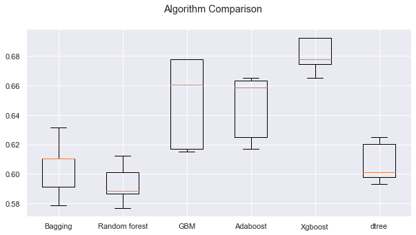

```python
# Plotting boxplots for CV scores of all models defined above
fig = plt.figure()

fig.suptitle("Algorithm Comparison")
ax = fig.add_subplot(111)

plt.boxplot(results)
ax.set_xticklabels(names)

plt.show()
```

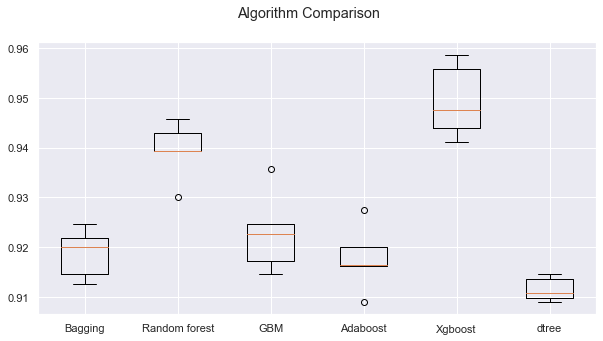

```python
# Plotting boxplots for CV scores of all models defined above
fig = plt.figure()

fig.suptitle("Algorithm Comparison")
ax = fig.add_subplot(111)

plt.boxplot(resultsoversample)
ax.set_xticklabels(namesoversample)

plt.show()
```

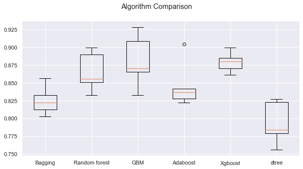

```python
# Plotting boxplots for CV scores of all models defined above
fig = plt.figure()

fig.suptitle("Algorithm Comparison")
ax = fig.add_subplot(111)

plt.boxplot(resultsundersample)
ax.set_xticklabels(namesundersample)

plt.show()
```

### Hyperparameter Tuning of 3 best Models.

I'm going to tune Random forest, Gradient Boosting and xgboost models using RandomizedSearchCV and further compare the performance of these three

```python
# defining a function to compute different metrics to check performance of a classification model built using sklearn
def model_performance_classification_sklearn(model, predictors, target):
    """
    Function to compute different metrics to check classification model performance

    model: classifier
    predictors: independent variables
    target: dependent variable
    """

    # predicting using the independent variables
    pred = model.predict(predictors)

    acc = accuracy_score(target, pred)  # to compute Accuracy
    recall = recall_score(target, pred)  # to compute Recall
    precision = precision_score(target, pred)  # to compute Precision
    f1 = f1_score(target, pred)  # to compute F1-score

    # creating a dataframe of metrics
    df_perf = pd.DataFrame(
        {"Accuracy": acc, "Recall": recall, "Precision": precision, "F1": f1,},
        index=[0],
    )

    return df_perf
```

```python
def confusion_matrix_sklearn(model, predictors, target):
    """
    To plot the confusion_matrix with percentages

    model: classifier
    predictors: independent variables
    target: dependent variable
    """
    y_pred = model.predict(predictors)
    cm = confusion_matrix(target, y_pred)
    labels = np.asarray(
        [
            ["{0:0.0f}".format(item) + "\n{0:.2%}".format(item / cm.flatten().sum())]
            for item in cm.flatten()
        ]
    ).reshape(2, 2)

    plt.figure(figsize=(6, 4))
    sns.heatmap(cm, annot=labels, fmt="")
    plt.ylabel("True label")
    plt.xlabel("Predicted label")
```

#### GradientBoostingClassifier

#### RandomizedSearchCV

```python
# Choose the type of classifier.
gbm_tuned = GradientBoostingClassifier(random_state=1)

# Grid of parameters to choose from
parameters = {
    "n_estimators": [100, 150, 200, 250],
    "subsample": [0.8, 0.9, 1],
    "max_features": [0.7, 0.8, 0.9, 1],
}


# Type of scoring used to compare parameter combinations
scorer = metrics.make_scorer(metrics.recall_score)

# Calling RandomizedSearchCV
randomized_cv = RandomizedSearchCV(
    estimator=gbm_tuned,
    param_distributions=parameters,
    n_iter=20,
    scoring=scorer,
    cv=5,
    random_state=1,
)

# Fitting parameters in RandomizedSearchCV
randomized_cv.fit(X_train_over, y_train_over)

print(
    "Best parameters are {} with CV score={}:".format(
        randomized_cv.best_params_, randomized_cv.best_score_
    )
)
```

```
Best parameters are {'subsample': 0.8, 'n_estimators': 250, 'max_features': 0.9} with CV score=0.883446919476162:
```

```python
# Random forest with best parameters
gbm_rs_tuned = GradientBoostingClassifier(
    random_state=1, subsample=0.8, max_features=0.9, n_estimators=250
)

# Fit the model on training data
gbm_rs_tuned.fit(X_train_over, y_train_over)
```

```
GradientBoostingClassifier(max_features=0.9, n_estimators=250, random_state=1,
                           subsample=0.8)
```

#### Checking GB model performance

```python
# Calculating different metrics on train set
gbm_random_train = model_performance_classification_sklearn(
    gbm_rs_tuned, X_train_over, y_train_over
)
print("Training performance:")
gbm_random_train
```

```
Training performance:
```

|  | Accuracy | Recall | Precision | F1 |
| --- | --- | --- | --- | --- |
| 0 | 0.953 | 0.951 | 0.956 | 0.953 |

```python
# Calculating different metrics on validation set
gbm_random_val = model_performance_classification_sklearn(gbm_rs_tuned, X_val, y_val)
print("Validation performance:")
gbm_random_val
```

```
Validation performance:
```

|  | Accuracy | Recall | Precision | F1 |
| --- | --- | --- | --- | --- |
| 0 | 0.896 | 0.692 | 0.669 | 0.681 |

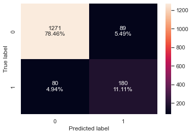

```python
# creating confusion matrix
confusion_matrix_sklearn(gbm_rs_tuned, X_val, y_val)
```

#### Observations

- On comparing the recall and precision, model is overfitting.
- The validation recall is around .69 i.e. the model is not good at identifying potential customers who would leave the CC product

### RandomizedSearchCV

```python
# Creating pipeline
model = RandomForestClassifier(random_state=1)

# Grid of parameters to choose from
## add from article
parameters = {
    "class_weight": [{0: 0.16, 1: 0.84}],
    "n_estimators": [100,150,200,250],
    "min_samples_leaf": np.arange(5, 10),
    "max_features": np.arange(0.2, 0.7, 0.1),
    "max_samples": np.arange(0.3, 0.7, 0.1),
}

# Type of scoring used to compare parameter combinations
scorer = metrics.make_scorer(metrics.recall_score)

# Calling RandomizedSearchCV
randomized_cv = RandomizedSearchCV(
    estimator=model,
    param_distributions=parameters,
    n_iter=20,
    scoring=scorer,
    cv=5,
    random_state=1,
)

# Fitting parameters in RandomizedSearchCV
randomized_cv.fit(X_train_over, y_train_over)

print(
    "Best parameters are {} with CV score={}:".format(
        randomized_cv.best_params_, randomized_cv.best_score_
    )
)
```

```
Best parameters are {'n_estimators': 200, 'min_samples_leaf': 9, 'max_samples': 0.6000000000000001, 'max_features': 0.2, 'class_weight': {0: 0.16, 1: 0.84}} with CV score=0.9650713309702905:
```

```python
# Creating new pipeline with best parameters
rfc_rs_tuned = RandomForestClassifier(
    class_weight={0: 0.16, 1: 0.84},
    n_estimators=200,
    max_samples=0.6,
    max_features=0.2,
    min_samples_leaf=9,
)


# Fit the model on training data
rfc_rs_tuned.fit(X_train_over, y_train_over)
```

```
RandomForestClassifier(class_weight={0: 0.16, 1: 0.84}, max_features=0.2,
                       max_samples=0.6, min_samples_leaf=9, n_estimators=200)
```

#### Checking RandomForestClassifier model performance

```python
# Calculating different metrics on train set
rad_random_train = model_performance_classification_sklearn(
    rfc_rs_tuned, X_train_over, y_train_over
)
print("Training performance:")
rad_random_train
```

```
Training performance:
```

|  | Accuracy | Recall | Precision | F1 |
| --- | --- | --- | --- | --- |
| 0 | 0.895 | 0.994 | 0.829 | 0.904 |

```python
# Calculating different metrics on validation set
rad_random_val = model_performance_classification_sklearn(rfc_rs_tuned, X_val, y_val)
print("Validation performance:")
rad_random_val
```

```
Validation performance:
```

|  | Accuracy | Recall | Precision | F1 |
| --- | --- | --- | --- | --- |
| 0 | 0.788 | 0.862 | 0.422 | 0.566 |

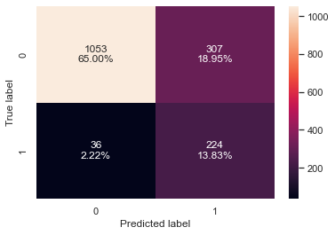

```python
# creating confusion matrix
confusion_matrix_sklearn(rfc_rs_tuned, X_val, y_val)
```

#### Observations

- Recall has improved on train and validation sets, still slightly overfitted. Precision has huge difference.
- Compared to GB model RandomClaissifer looks promising but let me evaluate the 3rd model beforeI come to any conclusion.

### XGBoost

#### RandomizedSearchCV

```python
%%time

# Choose the type of classifier.
model = XGBClassifier(random_state=1, eval_metric="logloss")

# Grid of parameters to choose from
parameters = {
    "n_estimators": [10, 30, 50],
    "scale_pos_weight": [1, 2, 5],
    "subsample": [0.7, 0.9, 1],
    "learning_rate": [0.05, 0.1, 0.2],
    "colsample_bytree": [0.7, 0.9, 1],
    "colsample_bylevel": [0.5, 0.7, 1],
}
# Type of scoring used to compare parameter combinations
scorer = metrics.make_scorer(metrics.recall_score)

# Calling RandomizedSearchCV
xgb_rs_tuned = RandomizedSearchCV(
    model, parameters, scoring=scorer, cv=5, random_state=1,n_iter=50
)

# Fitting parameters in RandomizedSearchCV
xgb_rs_tuned.fit(X_train_over, y_train_over)

print(
    "Best parameters are {} with CV score={}:".format(
        xgb_rs_tuned.best_params_, xgb_rs_tuned.best_score_
    )
)
```

```
Best parameters are {'subsample': 0.9, 'scale_pos_weight': 5, 'n_estimators': 10, 'learning_rate': 0.05, 'colsample_bytree': 0.7, 'colsample_bylevel': 1} with CV score=0.9795944044591156:
CPU times: user 5min 12s, sys: 7.32 s, total: 5min 19s
Wall time: 44.5 s
```

```python
# building model with best parameters
xgb_rs_tuned = XGBClassifier(
    random_state=1,
    n_estimators=10,
    scale_pos_weight=5,
    subsample=0.9,
    learning_rate=0.05,
    colsample_bytree=0.7,
    colsample_bylevel=1.0,
    eval_metric="logloss",
)
# Fit the model on training data
xgb_rs_tuned.fit(X_train_over, y_train_over)
```

```
XGBClassifier(base_score=0.5, booster='gbtree', colsample_bylevel=1.0,
              colsample_bynode=1, colsample_bytree=0.7,
              enable_categorical=False, eval_metric='logloss', gamma=0,
              gpu_id=-1, importance_type=None, interaction_constraints='',
              learning_rate=0.05, max_delta_step=0, max_depth=6,
              min_child_weight=1, missing=nan, monotone_constraints='()',
              n_estimators=10, n_jobs=8, num_parallel_tree=1, predictor='auto',
              random_state=1, reg_alpha=0, reg_lambda=1, scale_pos_weight=5,
              subsample=0.9, tree_method='exact', validate_parameters=1,
              verbosity=None)
```

#### Checking XGBoost model performance

```python
# Calculating different metrics on train set
xgboost_random_train = model_performance_classification_sklearn(
    xgb_rs_tuned, X_train_over, y_train_over
)
print("Training performance:")
xgboost_random_train
```

```
Training performance:
```

|  | Accuracy | Recall | Precision | F1 |
| --- | --- | --- | --- | --- |
| 0 | 0.858 | 0.992 | 0.782 | 0.875 |

```python
# Calculating different metrics on validation set
xgboost_random_val = model_performance_classification_sklearn(
    xgb_rs_tuned, X_val, y_val
)
print("Validation performance:")
xgboost_random_val
```

```
Validation performance:
```

|  | Accuracy | Recall | Precision | F1 |
| --- | --- | --- | --- | --- |
| 0 | 0.743 | 0.923 | 0.377 | 0.535 |

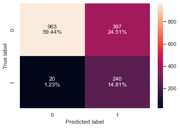

```python
# creating confusion matrix
confusion_matrix_sklearn(xgb_rs_tuned, X_val, y_val)
```

#### Observations

- Recall has improved quite significantly compared to other two models, still slightly overfitted.
- Precision has huge difference.

### Comparing 3 best models after huypertuning - RandomisedsearchCV

```python
# training performance comparison

models_train_comp_df = pd.concat(
    [gbm_random_train.T, rad_random_train.T, xgboost_random_train.T,], axis=1,
)
models_train_comp_df.columns = [
    "Gradient Boosting Tree Tuned with Random search",
    "RandomForest Tree Tuned with Random search",
    "Xgboost Tuned with Random Search",
]
print("Training performance comparison:")
models_train_comp_df
```

```
Training performance comparison:
```

|  | Gradient Boosting Tree Tuned with Random search | RandomForest Tree Tuned with Random search | Xgboost Tuned with Random Search |
| --- | --- | --- | --- |
| Accuracy | 0.953 | 0.895 | 0.858 |
| Recall | 0.951 | 0.994 | 0.992 |
| Precision | 0.956 | 0.829 | 0.782 |
| F1 | 0.953 | 0.904 | 0.875 |

```python
# Validation performance comparison

models_val_comp_df = pd.concat(
    [gbm_random_val.T, rad_random_val.T, xgboost_random_val.T,], axis=1,
)
models_val_comp_df.columns = [
    "Gradient Boosting Tree Tuned with Random search",
    "RandomForest Tree Tuned with Random search",
    "Xgboost Tuned with Random Search",
]
print("Validation performance comparison:")
models_val_comp_df
```

```
Validation performance comparison:
```

|  | Gradient Boosting Tree Tuned with Random search | RandomForest Tree Tuned with Random search | Xgboost Tuned with Random Search |
| --- | --- | --- | --- |
| Accuracy | 0.896 | 0.788 | 0.743 |
| Recall | 0.692 | 0.862 | 0.923 |
| Precision | 0.669 | 0.422 | 0.377 |
| F1 | 0.681 | 0.566 | 0.535 |

- XGBoost is giving better performance with RandomizedSearchCV having a validation recall of ~0.92
- I would like to use feature importance from the xgboost model tuned with Ramdom Search.

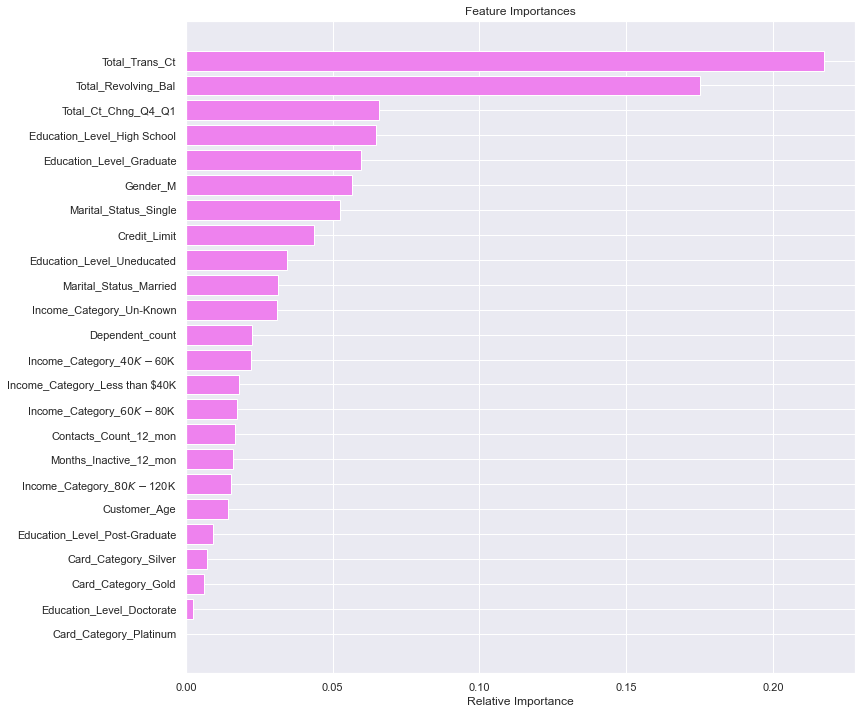

```python
feature_names = X_train.columns
importances = xgb_rs_tuned.feature_importances_
indices = np.argsort(importances)

plt.figure(figsize=(12, 12))
plt.title("Feature Importances")
plt.barh(range(len(indices)), importances[indices], color="violet", align="center")
plt.yticks(range(len(indices)), [feature_names[i] for i in indices])
plt.xlabel("Relative Importance")
plt.show()
```

- Total_Tran_Ct and Total_revolving_amount are the two most important variables which make sense as these variable play an important role in keeping customers as existing ones.
- I'm not sure how and why gender plays a role.

### Pipelines for productionizing the model

- Since the final model is identified. It is time to build pipelines to put the model into production.

### Column Transformer

The concept of pipelines is to standardize the model building, but the steps in a pipeline are applied to each and every variable. This is useful for heterogeneous or columnar data, to combine several feature extraction mechanisms or transformations into a single transformer. I'm going to create 2 different pipelines, one for numerical columns and one for categorical columns For numerical columns, I will do missing value imputation as pre-processing For categorical columns, I will do one hot encoding and missing value imputation as pre-processing

I'm going to doing missing value imputation for the whole data, so that if there is any missing value in the data in future that can be taken care of.

```python
# creating a list of numerical variables
numerical_features = [
    "Customer_Age",
    "Total_Trans_Ct",
    "Credit_Limit",
    "Total_Revolving_Bal",
    "Months_Inactive_12_mon",
    "Total_Ct_Chng_Q4_Q1",
    "Contacts_Count_12_mon",
]

# creating a transformer for numerical variables, which will apply simple imputer on the numerical variables
numeric_transformer = Pipeline(steps=[("imputer", SimpleImputer(strategy="median"))])

# creating a list of categorical variables
categorical_features = [
   "Gender",
    "Education_Level",
    "Marital_Status",
    "Income_Category",
    "Card_Category",
    "Dependent_count",

]

# creating a transformer for categorical variables, which will first apply simple imputer and
# then do one hot encoding for categorical variables
categorical_transformer = Pipeline(
    steps=[
        ("imputer", SimpleImputer(strategy="most_frequent")),
        ("onehot", OneHotEncoder(handle_unknown="ignore")),
    ]
)

# handle_unknown = "ignore", allows model to handle any unknown category in the test data

# combining categorical transformer and numerical transformer using a column transformer

preprocessor = ColumnTransformer(
    transformers=[
        ("num", numeric_transformer, numerical_features),
        ("cat", categorical_transformer, categorical_features),
    ],
    remainder="passthrough",
)
# remainder = "passthrough" has been used, it will allow variables that are present in original data
# but not in "numerical_columns" and "categorical_columns" to pass through the column transformer without any changes
```

```python
# Separating target variable and other variables
X = data.drop("Attrition_Flag", axis=1)
Y = data["Attrition_Flag"]
```

- Now we already know the best model we need to process with, so we don't need to divide data into 3 parts

```python
# Splitting the data into train and test sets
X_train, X_test, y_train, y_test = train_test_split(
    X, Y, test_size=0.30, random_state=1, stratify=Y
)
print(X_train.shape, X_test.shape)
```

```
(7087, 13) (3038, 13)
```

```python
# Creating new pipeline with best parameters
model = Pipeline(
    steps=[
        ("pre", preprocessor),
        (
            "XGB",
            XGBClassifier(
                random_state=1,
                n_estimators=10,
                scale_pos_weight=5,
                subsample=0.9,
                learning_rate=0.05,
                colsample_bytree=0.7,
                colsample_bylevel=1.0,
                eval_metric="logloss",
            ),
        ),
    ]
)
# Fit the model on training data
model.fit(X_train, y_train)
```

```
Pipeline(steps=[('pre',
                 ColumnTransformer(remainder='passthrough',
                                   transformers=[('num',
                                                  Pipeline(steps=[('imputer',
                                                                   SimpleImputer(strategy='median'))]),
                                                  ['Customer_Age',
                                                   'Total_Trans_Ct',
                                                   'Credit_Limit',
                                                   'Total_Revolving_Bal',
                                                   'Months_Inactive_12_mon',
                                                   'Total_Ct_Chng_Q4_Q1',
                                                   'Contacts_Count_12_mon']),
                                                 ('cat',
                                                  Pipeline(steps=[('imputer',
                                                                   SimpleImputer(strategy='...
                               eval_metric='logloss', gamma=0, gpu_id=-1,
                               importance_type=None, interaction_constraints='',
                               learning_rate=0.05, max_delta_step=0,
                               max_depth=6, min_child_weight=1, missing=nan,
                               monotone_constraints='()', n_estimators=10,
                               n_jobs=8, num_parallel_tree=1, predictor='auto',
                               random_state=1, reg_alpha=0, reg_lambda=1,
                               scale_pos_weight=5, subsample=0.9,
                               tree_method='exact', validate_parameters=1,
                               verbosity=None))])
```